# BAYESIAN INFERENCE FOR NORMAL MEAN WITH UNKNOWN MEAN AND VARIANCE

14 Apr 2021 (*updated: 2021-04-14)*

## i. Admin & Startup

## Why the likelihood function is not a probability distribution

- Thought I’d share something important to Bayesian/all of statistics with you.
- Discussion on iPad

## Week 12 of 16 Focus

- Receive and act on HW 7 Ch. 11-13, HW 8 Ch.14 feedback, HW 9 Ch.15, Ch.16
- Assess progress via Midterm 3 canvas quiz, due Friday Apr 9 16.
- Practice on HW 10 Ch.17 content.
- Read Ch.17
- HW 10. Ch.17 due Friday Apr 16.

## Today’s plan

- Prime by discussion via HW 10, Ch.17 exercise prompts.
- Finish Ch.17, part 1
- Discuss Ch.17, part 2
- Summarize, Revisit HW or Q & A

*Please contribute questions and comments*

## Ch.15, 16 HW discussion

- When using `Bolstad` functions don’t put the posterior values as the prior value!
- See (15.7) on p.329 for computing CI’s

```r
mu <- 15
y <- c(13.65, 14.31, 14.73, 13.88, 14.66, 15.53, 15.36, 15.16, 15.76, 18.55)
n <- length(y)
SST <- sum((y-mu)^2)
```

## Ch.15, 16 HW discussion

See (15.7) on p.329 for computing CI’s. Transform!

```r
Sprime <- SST; a <- 0.05; kappaPrime <- n ## Jeffrey's prior
l <- qchisq( a/2, kappaPrime, lower.tail = F) ## l is the chi-squared value having upper tail area alpha/2
u <- qchisq( a/2, kappaPrime, lower.tail = T) ## u is the chi-squared value having lower tail area alpha/2
lower <- sqrt(SST/l); upper <- sqrt(SST/u)
```

A 95% Bayesian Credible Interval for the Standard Deviation is (0.921, 2.312).

## Ch.15, 16 HW discussion

See Table 15.1 on p.330. Please report the p-value and conclusion — so I can easily check your work.

```r
a <- .05
sigma <- .05 ## weird that equals, alpha. Maybe meant 0.5?
W0 <- SST/sigma^2
(prob <- pchisq(W0, 10, lower.tail = F))
```

```
## [1] 0
```

```r
a <- .05
sigma <- 1 ## experimentation
W0 <- SST/sigma^2
(prob <- pchisq(W0, 10, lower.tail = F))
```

```
## [1] 0.06681431
```

## Ch.15, 16 HW discussion

Always check you work when possible

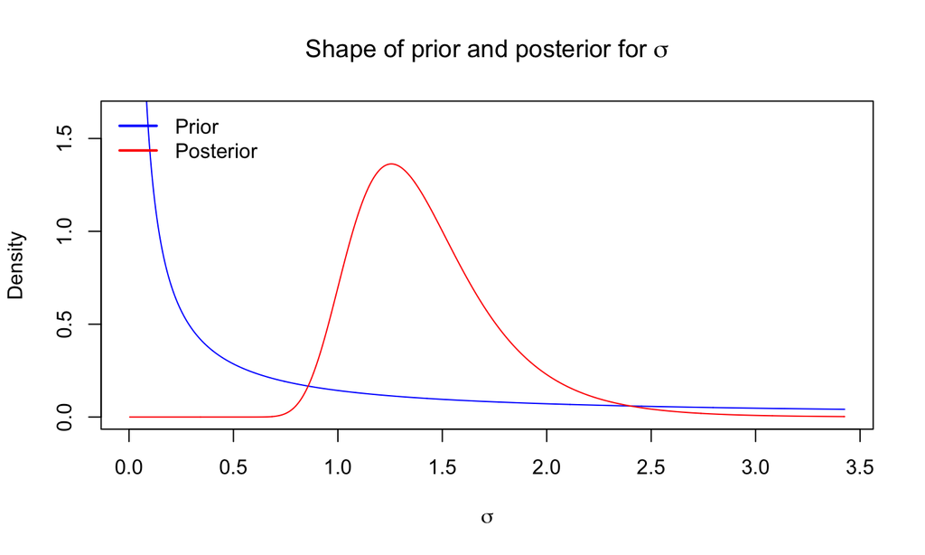

```
## S1: 17.36 kappa1 :10
```

```r
nvaricp(y, mu=15, 0, 0)
```

## Ch.16 C3 `normmixp`

Let’s explore the function `normmixp`

```r
normmixp
```

[output not shown]

The vector of \(\mu\) is created automatically around the prior!

## 16 C3

```r
sigma <- 5; m0 <- 1000; s0 <- 5
m1 <- 1000; s1 <- 15; p0 <- .95; p1 <- 1-p0
x <- c(1030, 1023, 1027, 1022, 1023, 1023, 1030, 1018, 1015, 1011)
n <- length(x); mean(x)
```

```
[1] 1022.2
```

## (a) Use **normmixp**

```r
results <- normmixp(x = x, sigma.x = sigma, prior0 = c(m0,s0), prior1 = c(m1,s1),
                    p = p0, mu = seq(980, 1060, length.out=1000), quiet=T )$mix
```

```
Integral of likelihood over mu:  0.99998
```

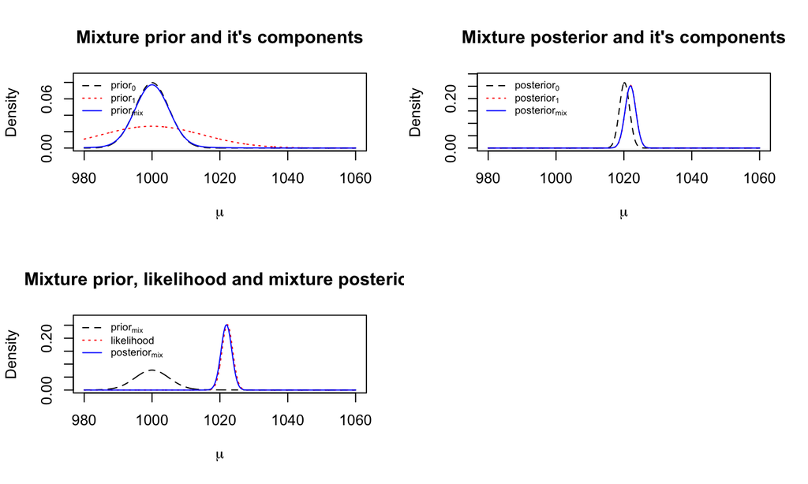

## (b) Find a 95% Bayesian credible interval for \(\mu\).

```r
ci <- quantile(results, probs = c(.025, .975))
```

```
Warning in regularize.values(x, y, ties, missing(ties), na.rm = na.rm):
collapsing to unique 'x' values
```

```r
cat(paste("95% Bayesian Credible Interval : (", round(ci[1], 3), ", ", round(ci[2], 3), ")", sep = ""))
```

```
95% Bayesian Credible Interval : (1018.744, 1024.985)
```

## (c) Test the hypothesis \(H_0 : \mu \leq 1,000\) vs. \(H_1 : \mu > 1,000\) at the 5% level of significance.

```r
mu0 <- 1000
Fmix <- cdf(results) ## see p.551
Fmix(mu0)
```

```
## [1] 1.114093e-42
```

```r
Fmix(mean(results)) ## compare to the mean
```

```
## [1] 0.506007
```

## I. Preview HW 10

- Ch.17: CI and C3, removed C2.

## Appendix

## Closing (5 min)

- Summary
- HW discussion
- other?